# Test a Perceptual Phenomenon

Lu

January 24, 2018

## Background Information

This is a statistical test of a perceptual Phenomenon: a Stroop task. In a Stroop task, participants are presented with a list of words, with each word displayed in a color of ink. The participant’s task is to say out loud the color of the ink in which the word is printed. The task has two conditions: a congruent words condition, and an incongruent words condition. In the congruent words condition, the words being displayed are color words whose names match the colors in which they are printed. In the incongruent words condition, the words displayed are color words whose names do not match the colors in which they are printed. In each case, we measure the time it takes to name the ink colors in equally-sized lists. Each participant will go through and record a time from each condition.

## What is independent variable? What is dependent variable?

The independent variable is congruent words condition and incongruent words condition.

The dependent variable is the time it takes to name the colors.

## What is an appropriate set of hypotheses for this task? What kind of statistiacal test do you expect to perform?

Hypotheses test:

1. The null hypothesis: the time that take to name the colors in equally-sized lists with congruent words condition and incongruent words condition are the same. H0: mu_diff = 0 (The difference between group population means is 0)
2. The alternative hypothesis: the time that take to name the colors in equally-sized lists with congruent words condition and incongruent words condition are not the same. H1: mu_diff != 0 (The difference between group population means is not 0)

## Some descriptive statistics

```
## 'data.frame':    24 obs. of  2 variables:
##  $ Congruent  : num  12.08 16.79 9.56 8.63 14.67 ...
##  $ Incongruent: num  19.3 18.7 21.2 15.7 22.8 ...
```

```
##    Congruent      Incongruent
##  Min.   : 8.63   Min.   :15.69
##  1st Qu.:11.90   1st Qu.:18.72
##  Median :14.36   Median :21.02
##  Mean   :14.05   Mean   :22.02
##  3rd Qu.:16.20   3rd Qu.:24.05
##  Max.   :22.33   Max.   :35.26
```

```
## [1] 3.559358
```

```
## [1] 4.797057
```

The dataset provides us with 24 observations of both congruent and incongruent words conditions. For congruent words condition: the mean is 14.05 and the standard deviation is 3.56. For incongruent words condition: the mean is 22.02 and the standard deviation is 4.80.

## Some visualizations that show the distribution of the sample data

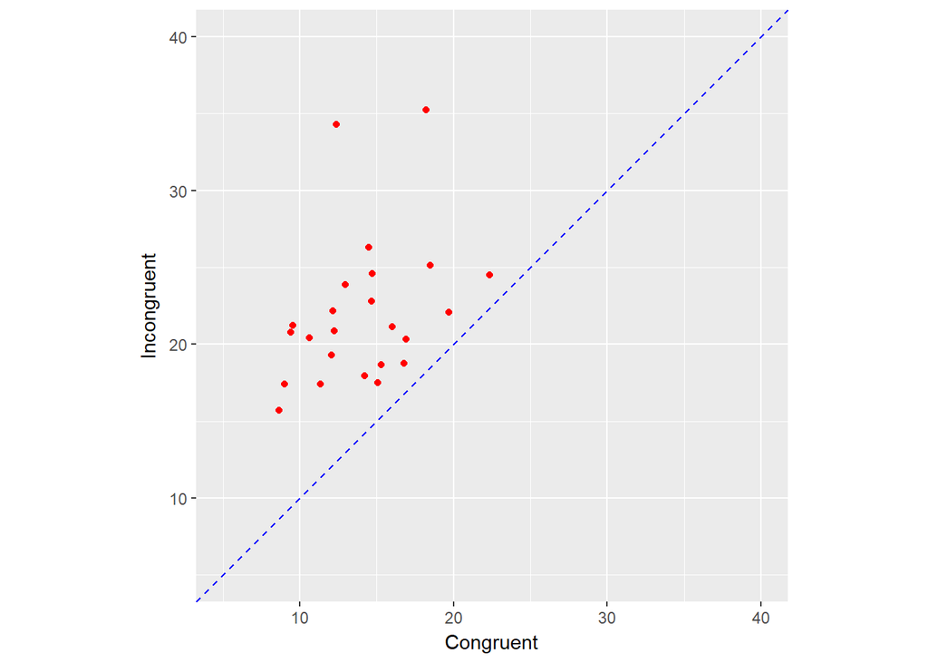

As shown in the plot, each red dot represent an observation: the x value is its congruent words condition time, and the y value is its incongruent words condition time. The dashed blue line represents y = x. It is obvious that incongruent words condition takes longer time to finish. Does this caused by random samples?

## Statistical test

Since the test used paired data, we will focus on the differences between the two groups:

```
## [1] 4.864827
```

```
## [1] -7.964792
```

```
## [1] -8.020707
```

As shown above, the differences have standard deviation of 4.86, average of -7.96, and a t-stat of -8.02.

On the other hand, the t-critical for 2 tailed test with significance level at 0.05: -2.07, 2.07.

The t-stat is in the left critical region, hence we reject the null hypothesis, which meets my expectation.

Also, with the help of online calculator, the p value is less than .01%, which means the difference is considered to be extremely statistically significant.

```
## [1] -10.02036
```

```
## [1] -5.909222
```

The confidence interval is (-10.02, -5.91), which means we have 95% confidence to believe the congruent test will take less time within the range than the incongruent test.

## What do you think is responsible for the effects observed?

I believe people’s mind is familiar with word. Once the word’s meaning of color is different from the color of the word, there are some conflicts in our mind and make it confused, hence taking longer time to finish the test.